# Machine Learning: ISLR Introduction

TerenceLiu98

2021-05-25

# Statsitical Learning

## What is Statistcal Learning

Statistical learning theory is a framework for machine learning drawing from the fields of statistics and functional analysis (Friedman et al. 2001). Statistical learning theory deals with the problem of finding a predictive function based on data. Statistical learning theory has led to successful applications in fields such as computer vision, speech recognition, and bioinformatics.

Intuitively, the learning process is the way to find out the mapping between input and output, no matter it is a regression problem or classification problem.

$$Y = f(X) + \epsilon$$

Where $f(\cdot)$ is the mapping function between the input ($X$) and the output ($Y$). $\epsilon$ is the random error. $f(\cdot)$ also represents the systematic information that $X$ provides about $Y$(James et al. 2013).

[figure not shown]

```python
import pandas as pd
import matplotlib.pyplot as plt
plt.style.use("ggplot")
data = pd.read_csv("dataset/advertising.csv")
plt.subplot(131)
plt.scatter(x = data["TV"], y=data["Sales"], marker="o", c = "r")
plt.xlabel("Sales")
plt.ylabel("TV")
plt.subplot(132)
plt.scatter(x = data["Radio"], y=data["Sales"], marker="o", c = "r")
plt.xlabel("Sales")
plt.ylabel("TV")
plt.subplot(133)
plt.scatter(x = data["Newspaper"], y=data["Sales"], marker="o", c = "r")
plt.xlabel("Sales")
plt.ylabel("TV")
plt.show()
```

## Why Estimate $\mathcal{f}$

Two reasons: Prediction and Inference

- Prediction: for prediction, we want to minimize the differ between $y$ and $\hat{y}$
- Inference: for inference, we care about the relationship between $X$ and $Y$; whether the estimation of $\hat{f}$ is significant; which parameters/variables is more important.

## How to estimate $\mathcal{f}$

There are multiple methods to estimate $f(\cdot)$:

- Linear Model, means $f(\cdot)$ is a linear function, e.g. linear regression, linear-SVM, k-NN, k-means, perceptron
- Non-Linear Model, means $f(\cdot)$ is a non-linear function, e.g. Kernel-SVM , AdaBoost, DNN, decision tree.

The above model can also be separated into parametric model and non-parametric model. The difference between these model is whether there is an assumption of data distribution:

- Parametric model: we assume the data comes from a distribution, then we use the data to estimate the parameters, e.g. perceptron, logistic regression, linear regression, gaussian mixture.
- Non-parametric model: distribution-free, or parameter-free, e.g. k-NN, SVM, decision tree, randomforest.

## Trade-off of Flexibility and Interpretability

$$\text{flexibility} \propto \frac{1}{\text{interpretability}}$$

## Supervised and Unsupervised Learning

- Supervised learning is a learning process **with** response $y_i$ (e.g. classification)
- Unsupervised learning is a learning process **without** response $y_i$ (e.g. clustering)

Compared with supervised learning, for unsupervised learning, there is no training process, data is directly used for modeling and analysis.

## Regression and Classification

The Predictive modeling is a process of training a mapping function $f(\cdot)$ from the input to the output, using the mapping function to predict the outcomes with the new input. The discovery of the input-output map is called function approximation.

- If the approximation is mapping the input to a **discrete space**, it is called classification;
- If the approximation is mapping the input to a **continuous space**, it is called regression.

## The Three elements in Statitiscal Learning

The methodology in Statistical learning has these three elements: model, strategy, and algorithm(Li 2019).

$$\text{Methodology} = \text{Model} + \text{Strategy} + \text{Algorithm}$$

### Model

Models usually have two taxonomies:

- probabilistic and non-probabilistic
- descriminative and generative

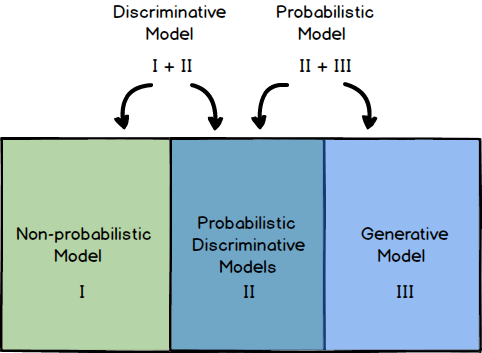

Classification

Model($f(\cdot)$) is a hypothesis space that includes all the possible conditional distribution or decision function $\mathcal{F}$.

For non-probabilistic model, it directly modeling the mapping $Y=f(X)$ from the input space to the output space. (e.g. Perceptron, MLP, SVM, k-NN); For probabilistic descriminative model, it focus on the conditional probability $P(Y|X)$ (e.g. logistic regression, Conditional Random Field(CRF)); For the generative model, it first estimate the joint probability $P(X,Y)$ and then calculate the conditional probability $P(Y|X)$ via the Bayes Theorem (e.g. Naive Bayes, HMM).

$$\begin{align}
\mathcal{F} &= \{f| Y=f(X)\} \Rightarrow \{f| Y=f_{\theta}(X), \theta \in \mathcal{R}^{n}\} \ \ &\text{decision function} \\
\mathcal{F} &= \{f| P|P(Y|X)\} \Rightarrow \{f| P|P_{\theta}(Y|X), \theta \in \mathcal{R}^{n}\} \ \ &\text{conditional distribution}
\end{align}$$

$\theta$ is the parameters, and $\mathcal{R}^{n}$ is the parameter space.

The difference between probabilistic and non-probabilistic is whether it is directly modeling from the input space to the output space. When there is enough data to accurately describe the probability distribution characteristics of uncertain parameters, the probabilistic model is more suitable; When we cannot get enough data or has less information on its distribution, we can choose non-probabilistic model.

### Strategy

For one dataset, different models give out different results and even using the same model it may give out different results. The Strategy part is focusing on how to choose a “good” model (choose the “good” parameter)

There are two kinds of error for a model: irreducible error and reducible error.

- Reducible error: is the error arising from the mismatch between $\hat{f}$ and $f$, where $f$ is the true relationship between $X$ and $Y$. To reduce the reducible error, we need to minimize the gap between estimate and the ground truth.
- Irreducible error: arises from the fact that $X$ does not completely determine $Y$. That is, there are variables outside of $X$ and these variables have some effect of $Y$. The only way to improve prediction error related to irreducible error is to identify these outside influences and incorporate them as predictors.

Assuming $\hat{Y} = \hat{f}(X) + \epsilon$, (where $\epsilon~N(0,\sigma^2)$), the error of $x$ is:

$$\begin{align*}
\operatorname {E} {\big [}(y-{\hat {f}})^{2}{\big ]} =&\operatorname {E} {\big [}(f+\varepsilon -{\hat {f}})^{2}{\big ]}\\
=&\operatorname {E} {\big [}(f+\varepsilon -{\hat {f}}+\operatorname {E} [{\hat {f}}]-\operatorname {E} [{\hat {f}}])^{2}{\big ]}\\
=&\operatorname {E} {\big [}(f-\operatorname {E} [{\hat {f}}])^{2}{\big ]}+\operatorname {E} [\varepsilon ^{2}]+\operatorname {E} {\big [}(\operatorname {E} [{\hat {f}}]-{\hat {f}})^{2}{\big ]}+2\operatorname {E} {\big [}(f-\operatorname {E} [{\hat {f}}])\varepsilon {\big ]}+2\operatorname {E} {\big [}\varepsilon (\operatorname {E} [{\hat {f}}]-{\hat {f}}){\big ]}+\\&2\operatorname {E} {\big [}(\operatorname {E} [{\hat {f}}]-{\hat {f}})(f-\operatorname {E} [{\hat {f}}]){\big ]}\\
=&(f-\operatorname {E} [{\hat {f}}])^{2}+\operatorname {E} [\varepsilon ^{2}]+\operatorname {E} {\big [}(\operatorname {E} [{\hat {f}}]-{\hat {f}})^{2}{\big ]}+2(f-\operatorname {E} [{\hat {f}}])\operatorname {E} [\varepsilon ]+2\operatorname {E} [\varepsilon ]\operatorname {E} {\big [}\operatorname {E} [{\hat {f}}]-{\hat {f}}{\big ]}+ \\ &2\operatorname {E} {\big [}\operatorname {E} [{\hat {f}}]-{\hat {f}}{\big ]}(f-\operatorname {E} [{\hat {f}}])\\
=&(f-\operatorname {E} [{\hat {f}}])^{2}+\operatorname {E} [\varepsilon ^{2}]+\operatorname {E} {\big [}(\operatorname {E} [{\hat {f}}]-{\hat {f}})^{2}{\big ]}\\
=&(f-\operatorname {E} [{\hat {f}}])^{2}+\operatorname {Var} [\varepsilon ]+\operatorname {Var} {\big [}{\hat {f}}{\big ]}\\
=&\underbrace{\underbrace{(f-\operatorname {E} [{\hat {f}}])^{2}}_{\text{Bias}}+\underbrace{\operatorname {Var} {\big [}{\hat {f}}{\big ]}}_{\text{Variance}}}_{\text{reducible error}} + \underbrace{\sigma^2}_{\text{irreducible error}}
\end{align*}$$

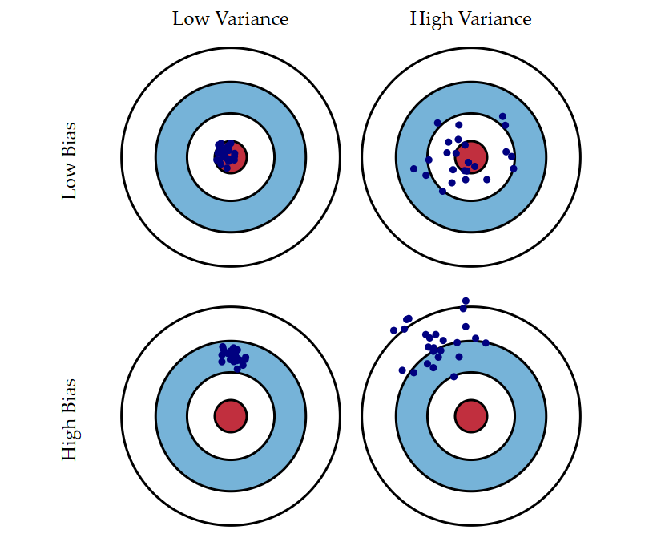

Reducible Error

- Bias is the statistic to describe the distance between expectation of predicted value and truth.
- Variance is the statistic to describe the performance of prediction in test set.
- irreducible error, also means systematic error.

#### Loss Function

Loss function is used to estimate whether the prediction is good or not, Here are some commonly used loss functions:

0-1 loss function:

$$L(Y, f(X)) = \left\{
\begin{array}{lr}
1, Y \neq f(X) \\
0, Y= f(X)
\end{array}
\right.$$

quadratic loss function:

$$L(Y, f(X)) = (Y-f(X))^2$$

absolute loss function:

$$L(Y, f(X)) = |Y-f(X)|$$

log-likelihood loss function:

$$L(Y, P(Y|X)) = -log(P(Y|X))$$

The average loss of a model is called **empirical risk** or **empirical loss**, $R_{emp}$:
$$R_{emp}(f) = \frac{1}{N} \sum_{i=1}^{N} L(y_i, f(x_i))$$

Friedman, Jerome, Trevor Hastie, Robert Tibshirani, and others. 2001. *The Elements of Statistical Learning*. Vol. 1. 10. Springer series in statistics New York.

James, Gareth, Daniela Witten, Trevor Hastie, and Robert Tibshirani. 2013. *An Introduction to Statistical Learning*. Vol. 112. Springer.

Li, Hang. 2019. *Statistical Learning Methods*. Tsinghua University Press.